# T&E Forecast

Anirut Worakitrungruang

9/12/2018

## Problem Background

T&E is a big portion of the company expense. We would like to be able to accurately forecast T&E and budget for it appropriately. Since financial planning activity occurs at a combination of cost center, account, and month granularity level, the prediction should be at the same level for it to be fully beneficial. Also, in terms of currency, financial planning is perfomed in USD; thus, it’s financial planning analyst’s responsibility to convert do currency conversion if their cost center’s local currency is not USD.

## Exploratory Data Analysis

Since T&E data comprises a few date fields, it’s considered a time series; thus can work with time series algorithms. The question now is “what date field should be used?”.

### Transaction Date

The argument about using transaction date is that it reflects the actual occurrences of expenses; however, it doesn’t actually reflect when the expenses get booked as actuals, which is what financial planning aims to match.

### Payment Date

It is most suited, except that it doesn’t have a value for all AirPlus expense types. Another downside to using payment date is that it doesn’t capture the actual flow of transactions because expenses for US cost centers are paid weekly and other cost centers are paid monthly. Thus, it throws away the actual flow of transaction movement.

### Submit Date

Submit date doesn’t mean much when it comes to being helpful for matching actuals. For example, a transaction that happened this month may not be added to a reimbursement report and submitted until next month.

In terms of amount, since the planning activity is performed in USD, it’s best to use the USD amount field that has the currency conversion already performed. Although one can argue that using USD amount drops some useful information about actual expenses, compared to using transaction currency, and let the fluctuation of currency value to influence the analysis and the model, let’s leave debate aside for now.

## Feature Engineering

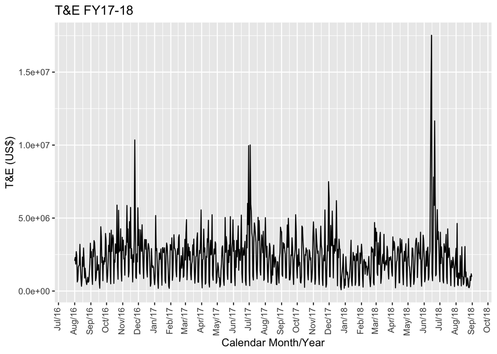

```r
# plot T&E by Transaction Date at day level
ggplot(df_usd_trns_dt, aes(TDate,x)) + geom_line() +
  scale_x_date(date_breaks = "1 month", date_labels = "%b/%y") +
  ggtitle("T&E FY17-18") +
  xlab("Calendar Month/Year") +
  ylab("T&E (US$)") +
  theme(axis.text.x = element_text(angle = 90, hjust = 1,vjust=0.3))
```

```r
# create a new data frame at month level
df_usd_trns_mo <- aggregate(df_usd_trns_dt$x, by=list(YYYYMM=df_usd_trns_dt$YYYYMM), FUN=sum)
df_usd_trns_mo$date <- as.Date(paste(df_usd_trns_mo$YYYYMM,"-01",sep=""))
df_usd_trns_mo$YYYY <- substr(df_usd_trns_mo$YYYYMM, 1, 4)
df_usd_trns_mo$MM <- substr(df_usd_trns_mo$YYYYMM, 6, 7)
```

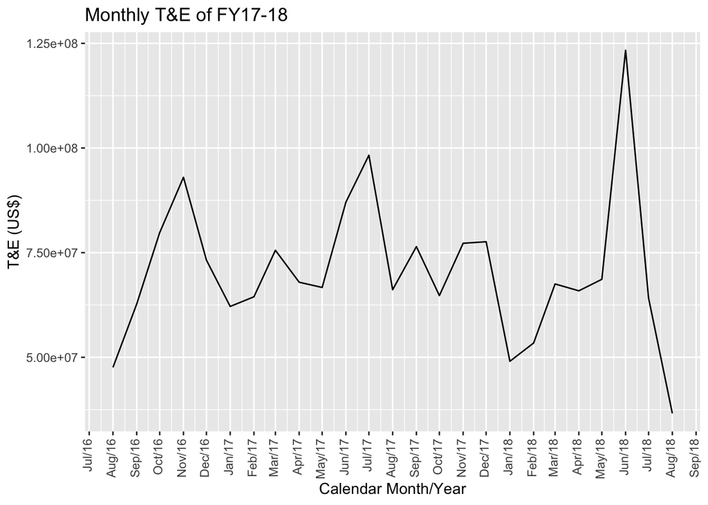

```r
# plot T&E by Transaction Date at month level
ggplot(df_usd_trns_mo, aes(date,x)) + geom_line() +
  scale_x_date(date_breaks = "1 month", date_labels = "%b/%y") +
  ggtitle("Monthly T&E of FY17-18") +
  xlab("Calendar Month/Year") +
  ylab("T&E (US$)") +
  theme(axis.text.x = element_text(angle = 90, hjust = 1,vjust=0.3))
```

```r
# create a time series at day level
startD_series <- as.numeric(format(head(df_usd_trns_dt$TDate, 1), "%j"))
startY_series <- as.numeric(strftime(head(df_usd_trns_dt$TDate, 1), format =" %Y"))
ts_te <- ts(df_usd_trns_dt$x, frequency=365.25, start=c(startY_series, startD_series))

# create a time series at day level for training
startD <- as.numeric(format(as.Date("2018-08-01"), "%j"))
ts_te_train <- window(ts_te, frequency=365.25, end=c(2018,startD))

# create a time series at day level for testing
# startD <- as.numeric(format(as.Date("2018-08-01"), "%j"))
ts_te_test <- window(ts_te, frequency=365.25, start=c(2018,startD))

# # create a time series at week level
# startW <- as.numeric(strftime(head(df_usd_trns_dt$TDate, 1), format = "%W"))
# startD <- as.numeric(strftime(head(df_usd_trns_dt$TDate, 1) + 1, format =" %w"))
# ts_te_wk <- ts(df_usd_trns_dt$x, frequency = 7, start = c(startW, startD))

# create a time series at month level
# ts_te_mo <- ts(df_usd_trns_mo$x, frequency=12, start=c(2016,8))
# ts_te_mo <- xts(df_usd_trns_mo$x, as.POSIXct(sprintf("%s-%s-01", df_usd_trns_mo$YYYY, df_usd_trns_mo$MM)))
# ts_te_mo <- xts(data$Level, as.yearmon(data$Year + (data$Month-1)/12))
# plot(ts_te_mo, main="T&E FY17-18 by Transaction Date")
```

```r
# create a data frame for plotting
df_plot <- df_usd_trns_dt
df_plot$type <- "Data"
TDate <- df_plot$TDate

# set forecasting period
h <- 31

# create a data frame for storing model selection metrics
df_metrics <- setNames(data.frame(matrix(ncol = 3, nrow = 0)), c("model", "metric", "value"))

# extract time series components
# ts_components <- decompose(ts_te_mo)
# plot(ts_components)

# function to plot data against model's fitted and forecast
func_plot_mdl <- function(ts, mdl, rslt, mdl_name) {
  # plot
  return(
  autoplot(ts, series="Data") +
    autolayer(mdl, series=mdl_name) +
    autolayer(rslt, series=mdl_name, alpha=0.3) +
    xlab("Calendar Month/Year") +
    ylab("T&E (USD)") +
    # scale_x_date(date_breaks = "1 month", date_labels = "%b/%y")
    scale_x_yearmon(format = "%b/%y", n=25) +
    theme(axis.text.x = element_text(angle = 90, hjust = 1,vjust=0.3))
  )
}

func_plot_rsdl <- function(rsdl) {
  # plot residuals diagnostics
  return(checkresiduals(rsdl))
  # acf(rsdl, lag.max=10)

  # box test -- if p is high, then there's little to no non-zero autocorrelation and thus, the model can no longer be improved upon.
  # Box.test(rsdl, lag=20, type="Ljung-Box")
}
```

## Moving Average

### Exponential Moving Average (EMA)

One of moving average techniques is Exponential Moving Average (EMA), which is to calculate (arithmetic) mean by giving higher weights to more recent values than older values, with the weights being exponentially tapered off. Fore more details, see https://www.fmlabs.com/reference/default.htm?url=ExpMA.htm, https://github.com/patharanordev/ema, https://oroboro.com/irregular-ema/

[output not shown]

```
## [1] "No. of periods with least RMSE: 10"
## [1] "Ratio to use with least RMSE: 1"
## [1] "RMSE: 166.014577791634"
## [1] "AIC: 24492.927168692"
```

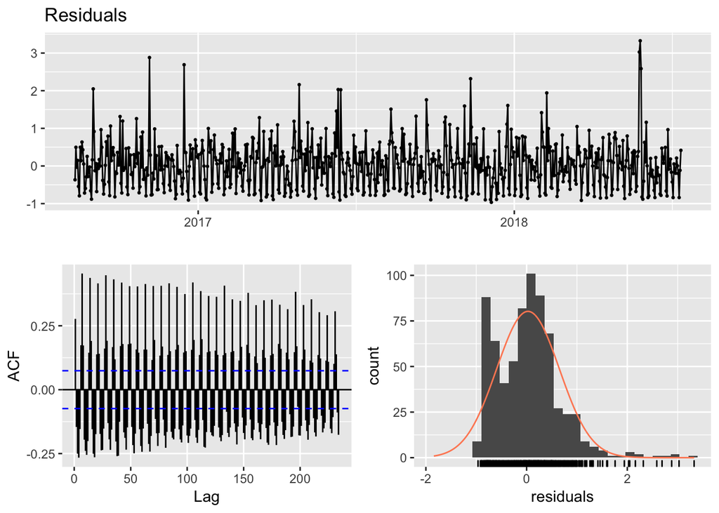

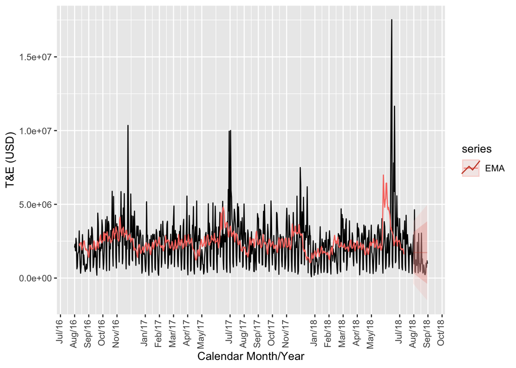

## Exponential Smoothing

### Simple Exponential Smoothing (SES)

Let’s start with Simple Exponential Smoothing (SES), the simplest of exponential smoothing techniques, which gives higher weights to the most recent values than distant past, based on the equation. Fore more details, see https://otexts.org/fpp2/ses.html

```
## [1] "RMSE: 1579240.15301462"
## [1] "AIC: 25656.7058952523"
```

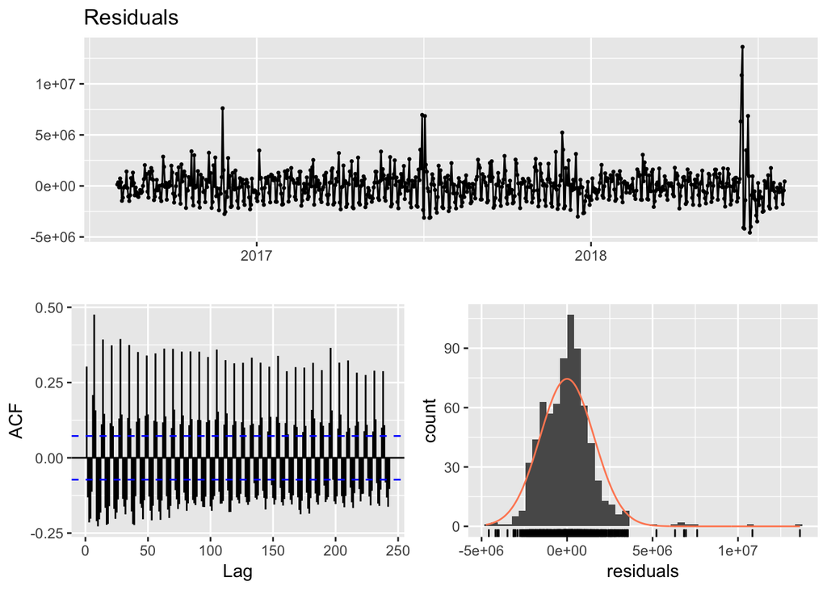

```r
func_SES <- function(ts_te_train, ts_te_test, df_metrics) {

  # create the model
  mdl_name <- "SES"
  mdl_ses <- ses(ts_te_train, h=length(ts_te_test))

  # RMSE
  RMSE_ses <- sqrt(mdl_ses$model$mse)
  print(paste("RMSE:", RMSE_ses))

  # AIC
  print(paste("AIC:", mdl_ses$model$aic))

  # forecast
  rslt_ses <- forecast(mdl_ses, h=length(ts_te_test))

  # store metrics
  df_metrics[nrow(df_metrics) + 1,] <- list(mdl_name, "RMSE", RMSE_ses)
  df_metrics[nrow(df_metrics) + 1,] <- list(mdl_name, "AIC", mdl_ses$model$aic)

  # plot results and residuals
  # dev.new()
  plt_rsdl <- func_plot_rsdl(mdl_ses$residuals)
  # dev.off()
  plt_mdl <- func_plot_mdl(ts(c(ts_te_train, ts_te_test),
                              start=start(ts_te_train),
                              frequency=frequency(ts_te_train)),
                           mdl_ses$fitted,
                           rslt_ses,
                           mdl_name)

  return(list(df_metrics=df_metrics, plt_rsdl=plt_rsdl, plt_mdl=plt_mdl))
}

# do SES
out <- func_SES(ts_te_train, ts_te_test, df_metrics)
```

```r
df_metrics <- out$df_metrics
out$plt_rsdl
```

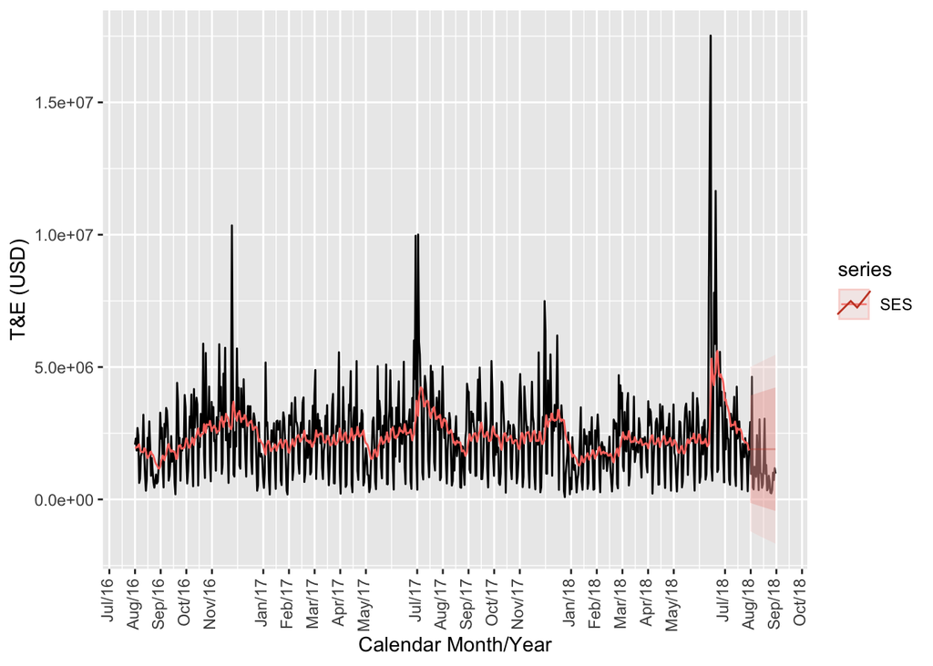

```r
out$plt_mdl
```

### Holt-Winters

As an extension to SES, Holt’s method is a linear method as an extension to that captures ‘trend’ in data. There are 3 equations involved: one is the forecast equation and two other are smoothing equations of level and trend. Fore more details, see https://otexts.org/fpp2/holt.html

Now, Holt-Winters is an extension to Holt’s method to additionally capture ‘seasonality’, with an added smoothing equation for seasonality. There are two variations to this method that differ in the nature of the seasonal component. The additive method is preferred when the seasonal variations are roughly constant through the series, while the multiplicative method is preferred when the seasonal variations are changing proportional to the level of the series. Unknown parameters are determined by minimizing the squared prediction error. Fore more details, see https://otexts.org/fpp2/holt-winters.html

Tableau Desktop’s forecast feature uses this technique, including both additive and multiplicative variations. And you can even select ‘Automatic’ option to allow Tableau Desktop to try all variations and select the best model for you. For more details, see https://onlinehelp.tableau.com/current/pro/desktop/en-us/forecast_how_it_works.html

## ETS (Error, Trend, and Seasonality)

ETS, based on the idea that the a time series has 3 components: trend, seasonality, and variance, is a method that’s similar to Holt-Winters, except that it tries to maximize the likelihood – as opposed to Holt-Winters’s minimizing sum squared error – when estimating smoothing parameters alpha, beta, gamma, etc.

```
## [1] "ETS model config: ETS(M,N,N)"
## [1] "RMSE: 1586253.71921568"
## [1] "AIC: 25507.21139199"
```

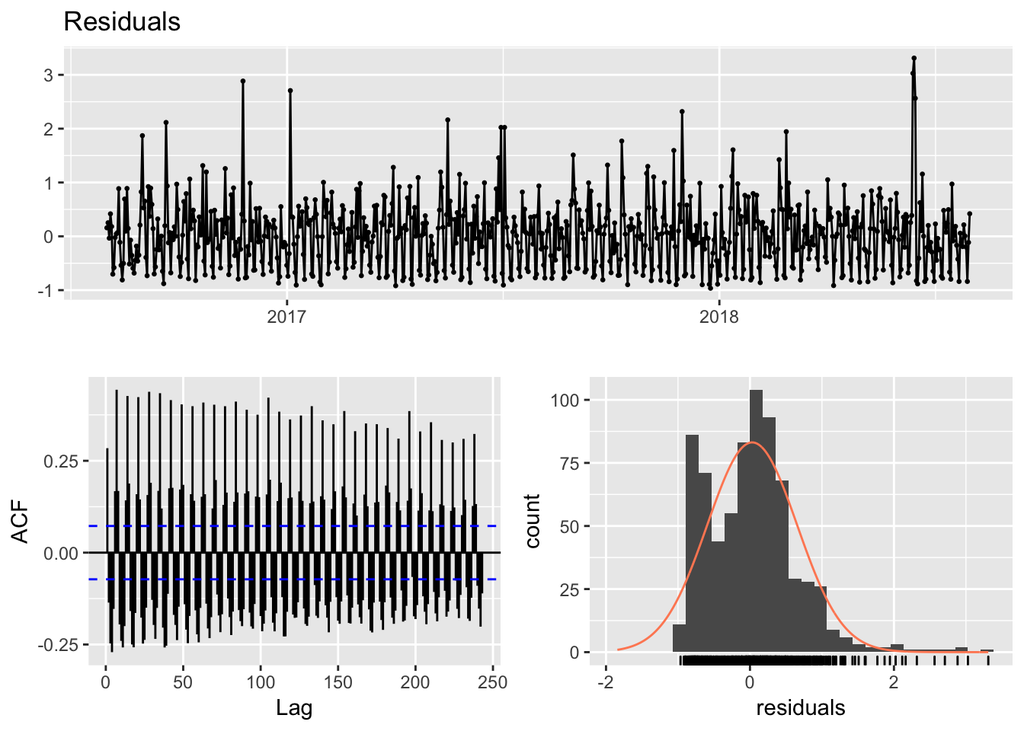

```r
func_ETS <- function(ts_te_train, ts_te_test, df_metrics) {

  # create the model
  mdl_name <- "ETS"
  mdl_ets <- ets(ts_te_train, model="ZZN")
  print(paste(mdl_name, "model config:", mdl_ets))

  # RMSE
  RMSE_ets <- sqrt(mdl_ets$mse)
  print(paste("RMSE:", RMSE_ets))

  # AIC
  print(paste("AIC:", mdl_ets$aic))

  # store metrics
  df_metrics[nrow(df_metrics) + 1,] <- list(mdl_name, "RMSE", RMSE_ets)
  df_metrics[nrow(df_metrics) + 1,] <- list(mdl_name, "AIC", mdl_ets$aic)

  # forecast
  rslt_ets <- forecast(mdl_ets, h=length(ts_te_test))

  # plot results and residuals
  # dev.new()
  plt_rsdl <- func_plot_rsdl(mdl_ets$residuals)
  # dev.off()
  plt_mdl <- func_plot_mdl(ts(c(ts_te_train, ts_te_test),
                              start=start(ts_te_train),
                              frequency=frequency(ts_te_train)),
                           mdl_ets$fitted,
                           rslt_ets,
                           mdl_name)

  return(list(df_metrics=df_metrics, plt_rsdl=plt_rsdl, plt_mdl=plt_mdl))
}

# do ETS
out <- func_ETS(ts_te_train, ts_te_test, df_metrics)
```

```r
df_metrics <- out$df_metrics
out$plt_rsdl
```

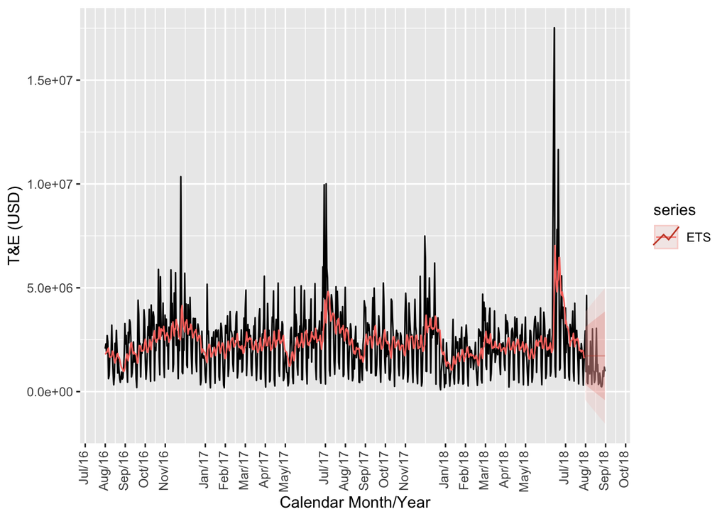

```r
out$plt_mdl
```

## ARIMA

To be able to use ARIMA, we have to ensure that our data is “stationary”, i.e., it doesn’t contain trend and seasonality.

For ARIMA, we can perform Ljung Box test on residuals to enture that there’s no correlation left between adjacent values.

```
## [1] "Auto ARIMA model config: ARIMA(0,0,2) with non-zero mean"
## [1] "RMSE: 1463158.71224162"
## [1] "AIC: 22806.1921420173"
```

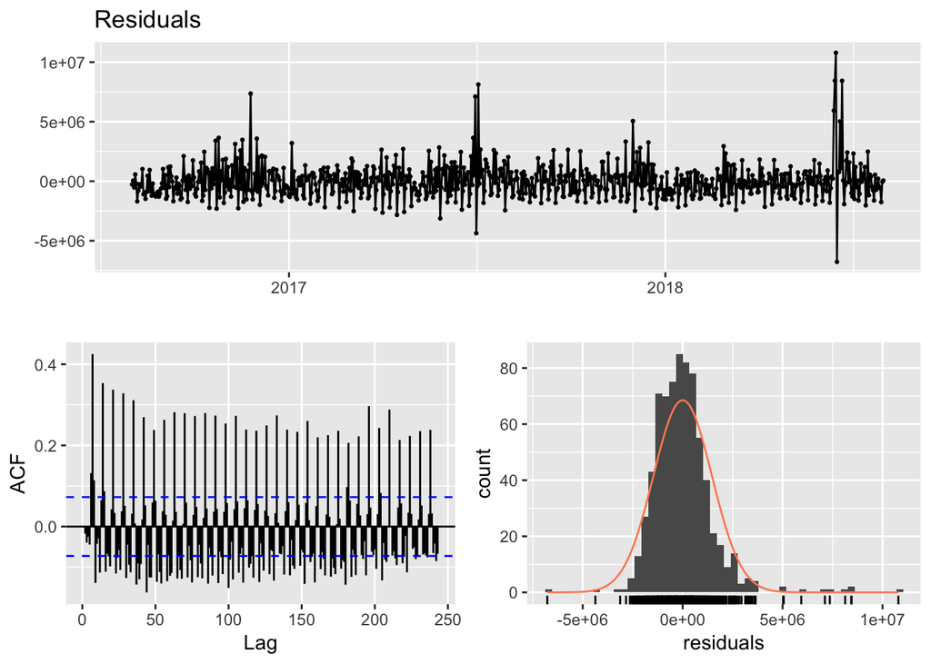

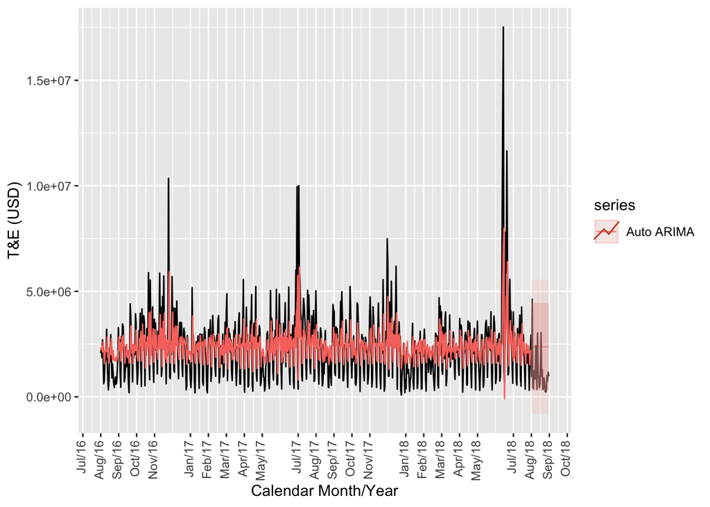

## Model Benchmarking

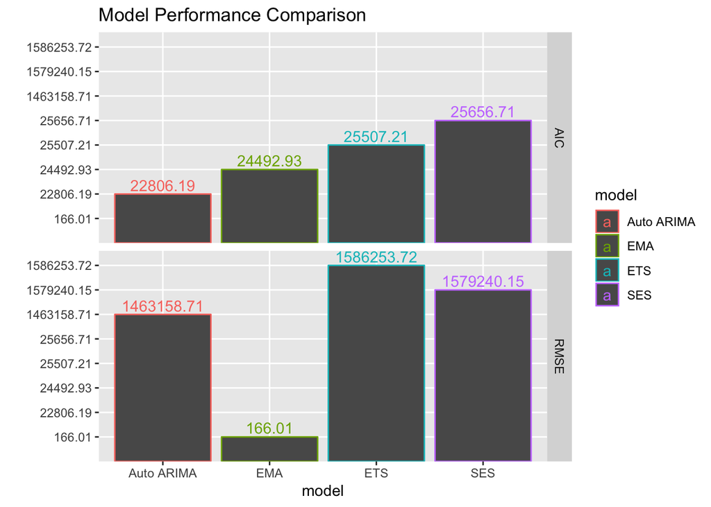

```r
df_metrics_plot <- df_metrics[as.numeric(rownames(unique(df_metrics[1:2]))),]
df_metrics_plot$value <- sapply(df_metrics_plot$value, round, 2)

ggplot(data=df_metrics_plot, aes(x=model, y=format(round(value, 2), nsmall=2), color=model)) +
  ggtitle("Model Performance Comparison") +
  geom_bar(stat="identity") +
  geom_text(aes(label=value), vjust=-0.3) +
  facet_grid(metric~.) +
  ylab("")
```

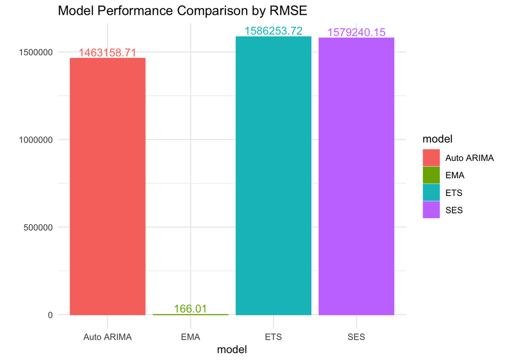

```r
ggplot(data=subset(df_metrics_plot, metric=="RMSE"), aes(x=model, y=value, color=model, fill=model)) +
  ggtitle("Model Performance Comparison by RMSE") +
  geom_bar(stat="identity") +
  theme_minimal() +
  geom_text(aes(label=value), vjust=-0.3) +
  ylab("")
```

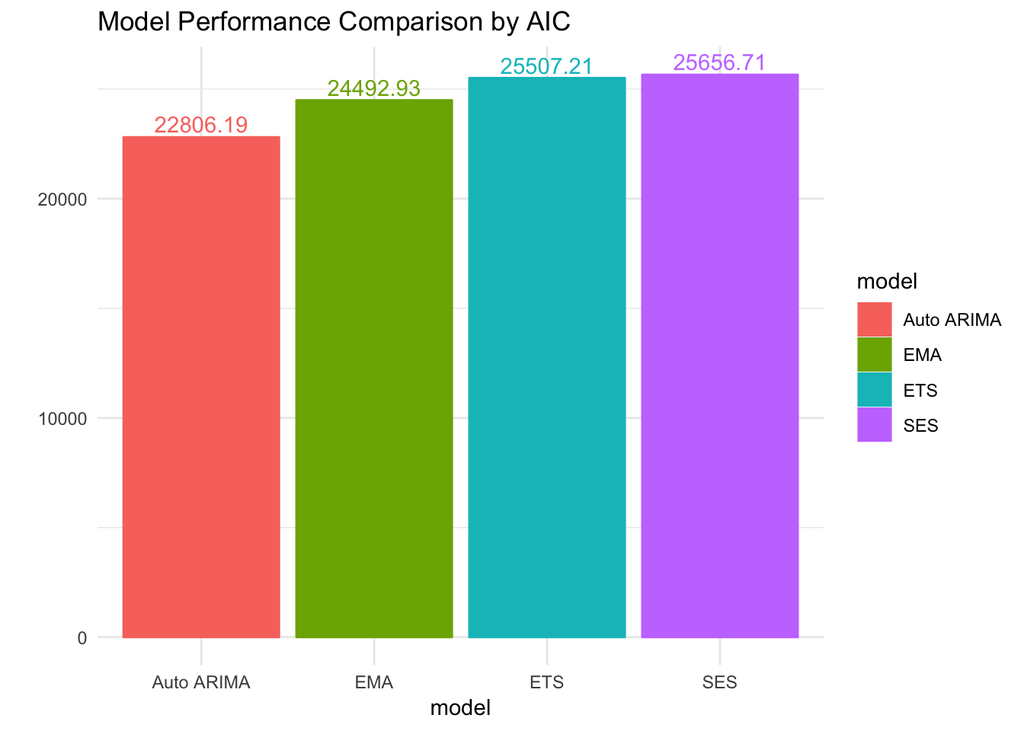

```r
ggplot(data=subset(df_metrics_plot, metric=="AIC"), aes(x=model, y=value, color=model, fill=model)) +
  ggtitle("Model Performance Comparison by AIC") +
  geom_bar(stat="identity") +
  theme_minimal() +
  geom_text(aes(label=value), vjust=-0.3) +
  ylab("")
```

## Creating Models for Each Combination of Cost Center, Account, and Month

This process can also be repeated for each of the date fields to determine which of them is best suited for this task.

## Improvement Ideas

1. Data to use for this analysis and model creation can be actuals from SAP because actuals are what the predictive model’s results are supposed to match.
2. Date granularity 2.1 when building model and making predictions, data at a lower level, such as day or week (or even month level), should be used, in order to utilize the granularity level of data. It’s only when presenting the predicted values that they can be aggregated up to month level.
3. Use Paid Date
4. Test against September actuals